# VLM Wrong Predictions: attr_material_frame_tank_body [embed_only]

Asset 92085 2 images

Predicted: VLM: Timber/Wood | DINOv3: Box Step (conf: N/A)

Actual: Box Step

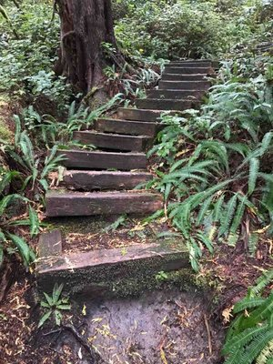

27387__AST_IM_20211013_093835.jpeg

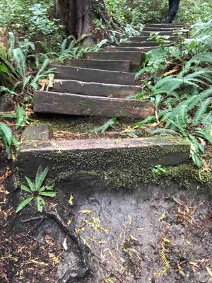

27395__AST_IM_20211013_093846.jpeg

Asset 92433 10 images

Predicted: VLM: Timber/Wood | DINOv3: Box Step (conf: N/A)

Actual: Box Step

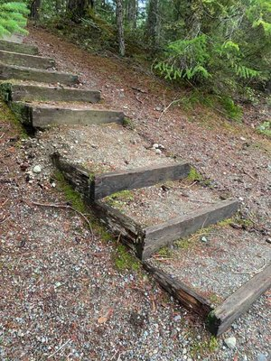

28324__AST_IM_20211019_132249.jpeg

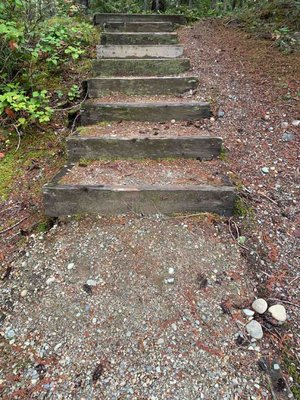

28326__AST_IM_20211019_132238.jpeg

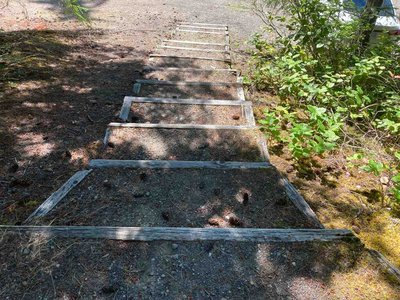

55969__AST_EX_20220725_141410.jpeg

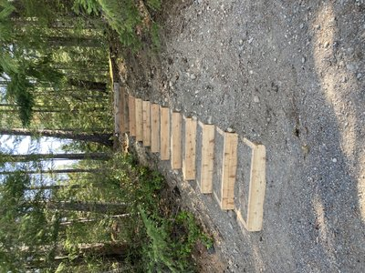

65795__IMG_0769.JPG

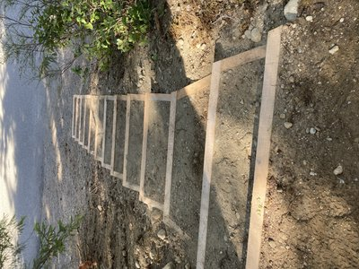

65796__IMG_0771.JPG

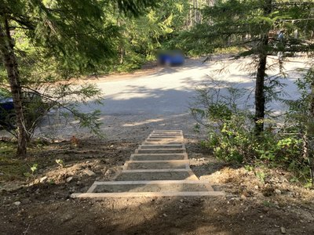

65797__IMG_0770.JPG

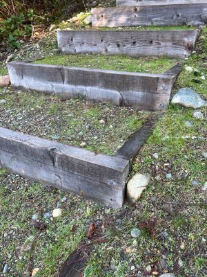

78486__AST_EX_20250121_115432.jpeg

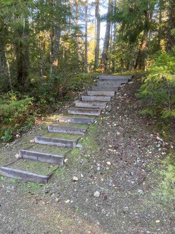

78487__AST_EX_20250121_115424.jpeg

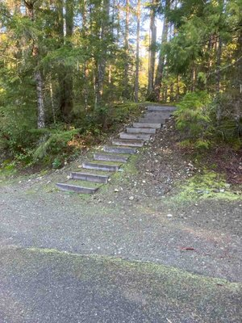

78510__AST_EX_20250121_115709.jpeg

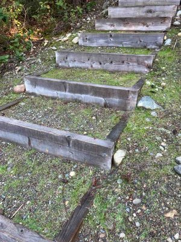

78530__AST_EX_20250121_115716.jpeg

Asset 92436 10 images

Predicted: VLM: Timber/Wood | DINOv3: Box Step (conf: N/A)

Actual: Box Step

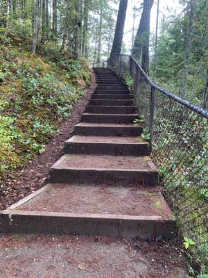

28285__AST_IM_20211019_150127.jpeg

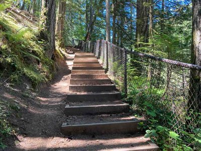

55972__AST_EX_20220725_122238.jpeg

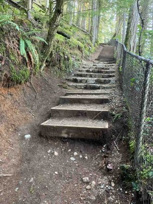

78511__AST_EX_20250121_123539.jpeg

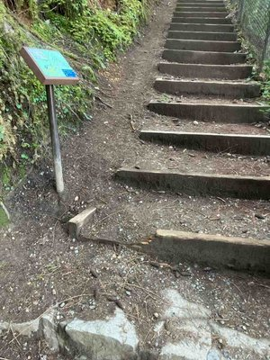

78513__AST_EX_20250121_123340.jpeg

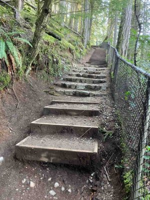

78514__AST_EX_20250121_123529.jpeg

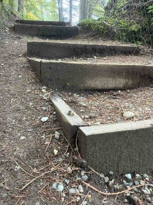

78516__AST_EX_20250121_123307.jpeg

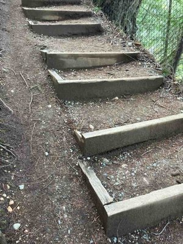

78518__AST_EX_20250121_123333.jpeg

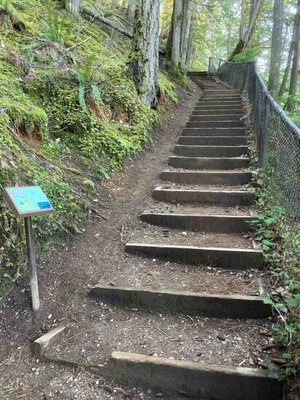

78519__AST_EX_20250121_123347.jpeg

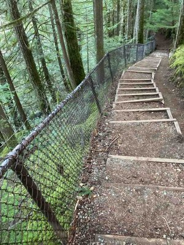

78528__AST_EX_20250121_123246.jpeg

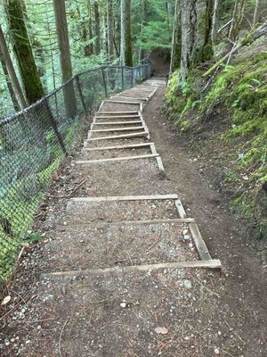

78529__AST_EX_20250121_123235.jpeg

Asset 93359 4 images

Predicted: VLM: Timber/Wood | DINOv3: Box Step (conf: N/A)

Actual: Box Step

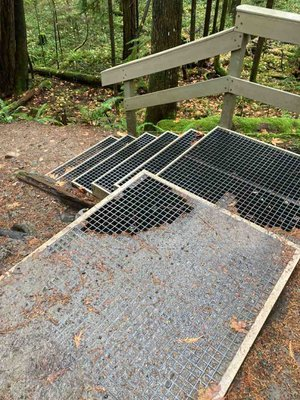

30850__AST_IM_20211104_105345.jpeg

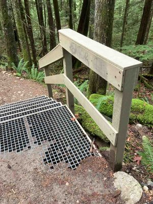

77878__AST_EX_20241128_120218.jpeg

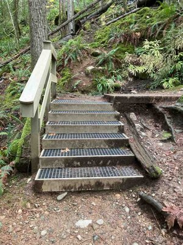

77879__AST_EX_20241128_120230.jpeg

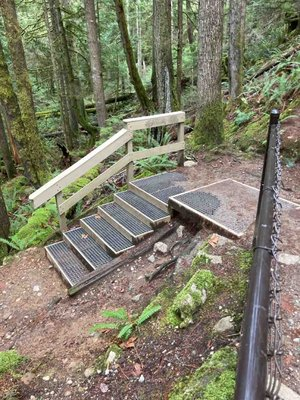

77881__AST_EX_20241128_120209.jpeg

Asset 94137 1 image

Predicted: VLM: Timber/Wood | DINOv3: Concrete (conf: N/A)

Actual: Concrete

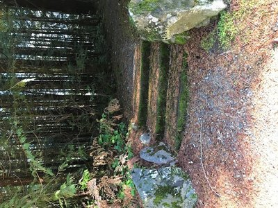

33321__18_Stairs_North_side_of_Parking_Area_1.jpg

Asset 101607 1 image

Predicted: VLM: Timber/Wood | DINOv3: Box Step (conf: N/A)

Actual: Box Step

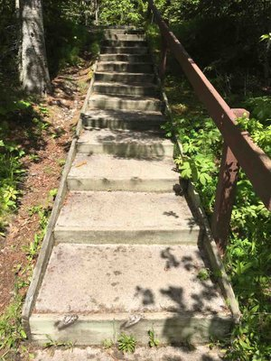

45847__AST_IM_20220610_125112.jpeg

Asset 101624 1 image

Predicted: VLM: Timber/Wood | DINOv3: Box Step (conf: N/A)

Actual: Box Step

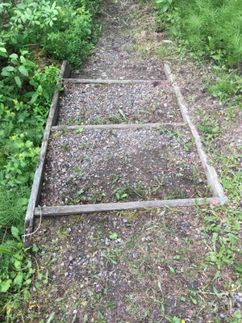

45867__AST_IM_20220610_145154.jpeg

Asset 103909 1 image

Predicted: VLM: Timber/Wood | DINOv3: Box Step (conf: N/A)

Actual: Box Step

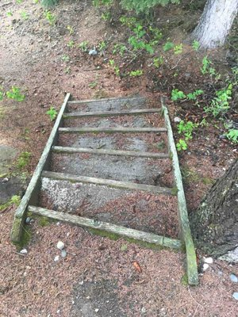

48995__AST_IM_20220621_164654.jpeg

Asset 104861 2 images

Predicted: VLM: Timber/Wood | DINOv3: Concrete (conf: N/A)

Actual: Concrete

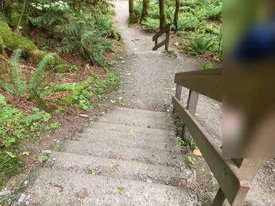

50114__AST_IM_20220628_113252.jpeg

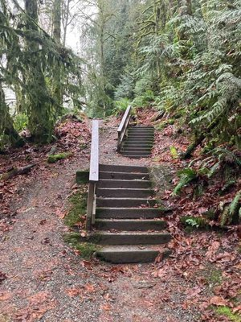

77729__AST_EX_20241122_105922.jpeg

Asset 104870 2 images

Predicted: VLM: Timber/Wood | DINOv3: Box Step (conf: N/A)

Actual: Box Step

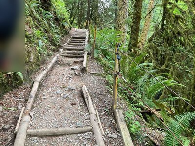

50124__AST_IM_20220628_114723.jpeg

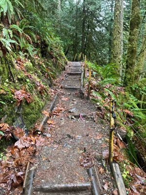

77731__AST_EX_20241122_111336.jpeg

Asset 105082 1 image

Predicted: VLM: Timber/Wood | DINOv3: Box Step (conf: N/A)

Actual: Box Step

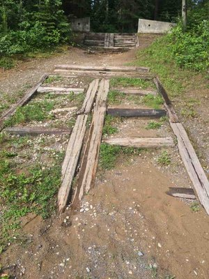

50964__AST_IM_20220629_095551.jpeg

Asset 105083 1 image

Predicted: VLM: Timber/Wood | DINOv3: Box Step (conf: N/A)

Actual: Box Step

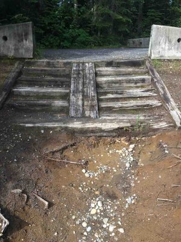

50959__AST_IM_20220629_095644.jpeg

Asset 105616 2 images

Predicted: VLM: Timber/Wood | DINOv3: Box Step (conf: N/A)

Actual: Box Step

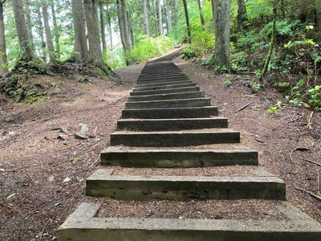

51601__AST_IM_20220705_112509.jpeg

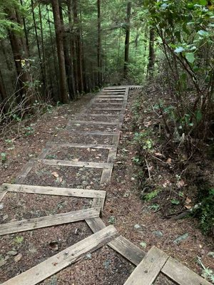

77908__AST_EX_20241126_130644.jpeg